# Ordinary Least Squares Regression

## Example of an OLS regression in R

In R, the `lm` function command allows us to develop an OLS regression.

```r
# model predicting mpg (fuel efficiency) using wt (weight)
MPGReg <- lm(mpg ~ wt, data = mtcars)
summary(MPGReg)

Call:
lm(formula = mpg ~ wt, data = mtcars)

Residuals:
   Min     1Q Median     3Q    Max
-4.543 -2.365 -0.125  1.410  6.873

Coefficients:
            Estimate Std. Error t value Pr(>|t|)
(Intercept)   37.285      1.878   19.86  < 2e-16 ***
wt            -5.344      0.559   -9.56  1.3e-10 ***
---
Signif. codes:  0 '***' 0.001 '**' 0.01 '*' 0.05 '.' 0.1 ' ' 1

Residual standard error: 3.05 on 30 degrees of freedom
Multiple R-squared:  0.753, Adjusted R-squared:  0.745
F-statistic: 91.4 on 1 and 30 DF,  p-value: 1.29e-10
```

The OLS regression model is then:

$\widehat{MPG_i} = 37.285 - 5.344*WT_i$

- **Interpretation:** $\beta_0$
  - The model predicts that vehicles with no weight will have 37.285 miles per gallon, on average.
  - This is not a very meaningful intercept as vehicles with “0” weight do not exist. A meaningful intercept can be created by subtracting a constant from the *x* variable to move the intercept.In R as part of the `lm` command, this can be done by surrounding the independent variable with `I()` which applies the function inside and treats it as a new variable. For our example we used the rounded lowest weight of the data (1.5) to predict miles per gallon.

    > This procedure does not change the slope of the line

```r
# model predicting mpg (fuel efficiency) using wt (weight)
MPGReg2 <- lm(mpg ~ I(wt-1.5), data = mtcars)
summary(MPGReg2)

Call:
lm(formula = mpg ~ I(wt - 1.5), data = mtcars)

Residuals:
   Min     1Q Median     3Q    Max
-4.543 -2.365 -0.125  1.410  6.873

Coefficients:
            Estimate Std. Error t value Pr(>|t|)
(Intercept)   29.268      1.101   26.59  < 2e-16 ***
I(wt - 1.5)   -5.344      0.559   -9.56  1.3e-10 ***
---
Signif. codes:  0 '***' 0.001 '**' 0.01 '*' 0.05 '.' 0.1 ' ' 1

Residual standard error: 3.05 on 30 degrees of freedom
Multiple R-squared:  0.753, Adjusted R-squared:  0.745
F-statistic: 91.4 on 1 and 30 DF,  p-value: 1.29e-10
```

- Then, the meaningful intercept model predicts that vehicles with a weight of 1500 pounds have 29.268 miles per gallon, on average.
- **Interpretation:** $\beta_1$
  - The model predicts that on average, an increase of 1,000 pounds in the weight of a vehicle is associated with a decrease of 5.344 miles per gallon.

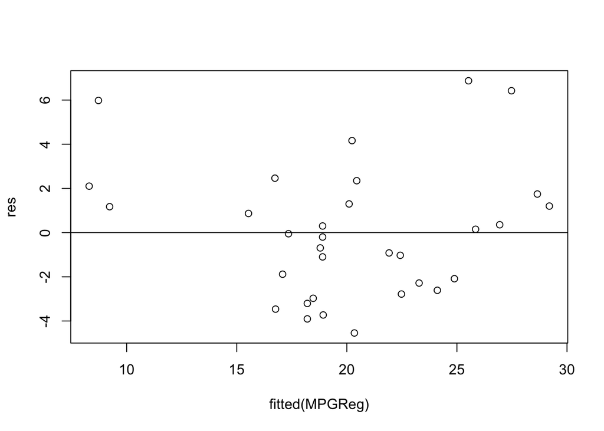

```r
# define residuals
res <- resid(MPGReg)

# produce residual vs. fitted plot
plot(fitted(MPGReg), res)

# add a horizontal line at 0
abline(0,0)
```

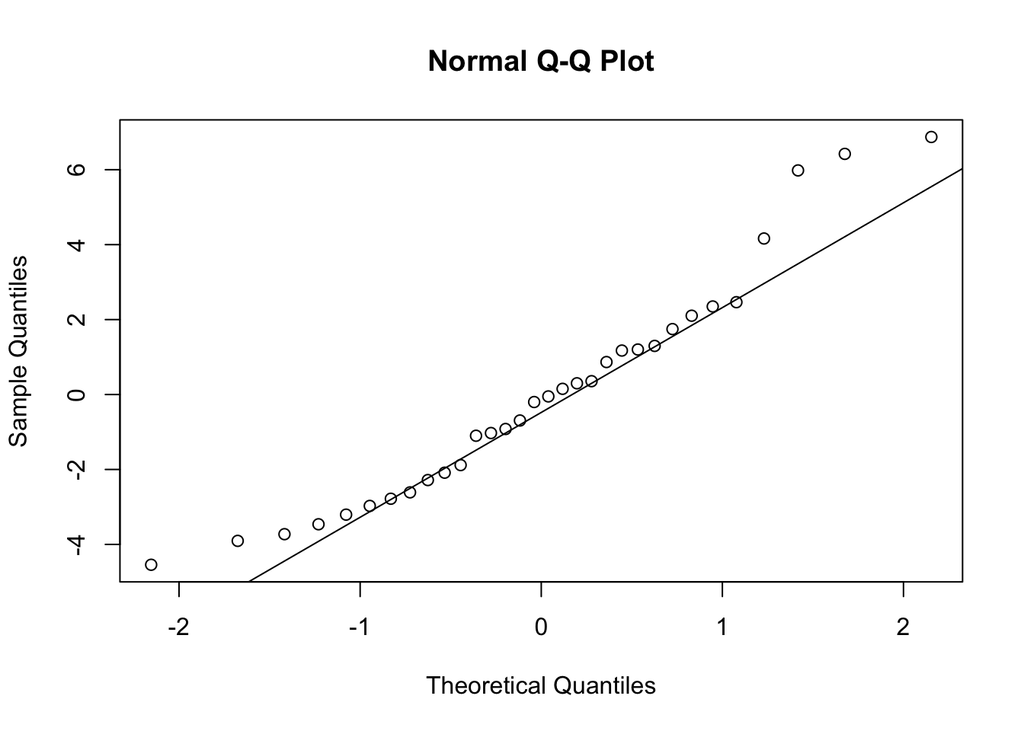

```r
# create Q-Q- plot for residuals
qqnorm(res)

# add a straight diagonal line to the plot
qqline(res)
```

Based on the graph above, it is visually clear that normality may not be met due to some outliers. This means that we must explore our data even deeper as it is possible that transformation of our data utilizing one of the following methods must take place:

> Log transformation Square Root Transformation Cube Root Transformation

Once the data is transformed, we can run the residual plot over again in order to achieve normality. For the sake of this presentation, we are only using an example with known limitations such as non-normality.

## Hypothesis testing in OLS regression

The null hypothesis in this case would be that the slope is zero indicating no relationship between x and y. Or in our example, we can state that there is no relationship between a vehicle’s weight and its miles per gallon. The alternative hypothesis is then that the slope is not zero.

$$H_0: \beta_1 = 0$$

$$H_1: \beta_1 ≠ 0$$

We can test this hypothesis by using the `lm summary` printout which provides the p-value for the `wt` coefficient. This indicates that there is indeed a significant relationship between the weight of the car and its efficiency (miles per gallon used). R provides a t-value for the ‘wt’ coefficient which has a p-value of p < 0.000 as seen below:

```
                  Estimate        Std. Error       t value      Pr(>|t|)
    wt           -5.3445             0.5591       -9.559       1.29e-10
```

## Visual representation

The visual representation of this model using `ggplot` is the following:

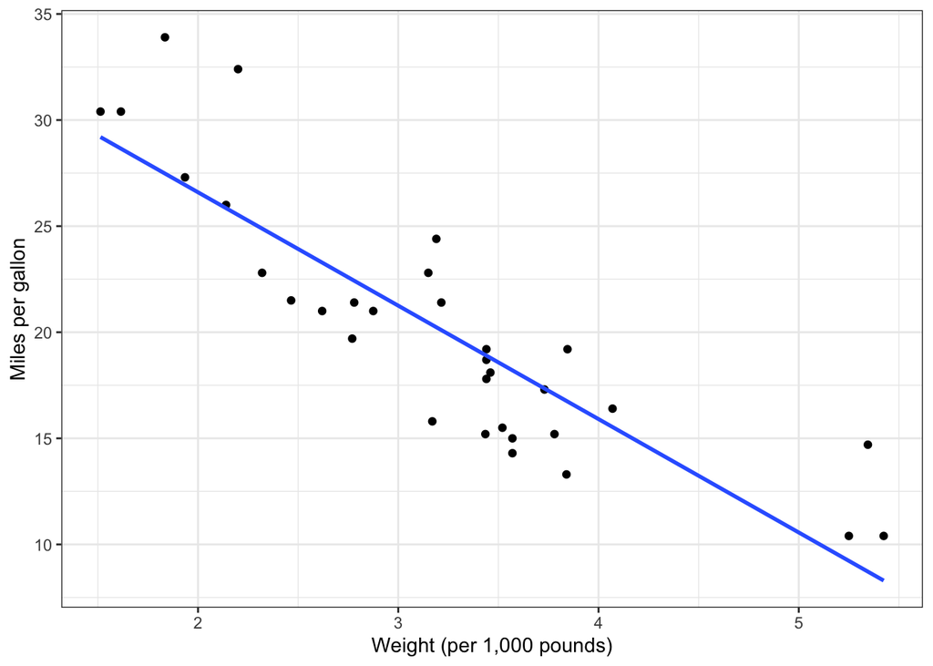

```r
ggplot(mtcars, aes(x = wt, y = mpg))+
  geom_point()+
  geom_smooth(method = "lm", se = FALSE)+ #se is option for coinfidence bar
  labs(x= "Weight (per 1,000 pounds)",
       y = "Miles per gallon")+
  theme_bw()
`geom_smooth()` using formula = 'y ~ x'
```

As shown in the figure above, we see the summary statistics represented in a visual manner with the line of best fit. As indicated previously, we see a steep negative correlation between weight of the car and the miles per gallon (efficiency) utilized.